# matplotlib.pyplot.title

**matplotlib.pyplot.title(*label*, *fontdict=None*, *loc=None*, *pad=None*, *, *y=None*, **kwargs)[[source]](https://github.com/matplotlib/matplotlib/blob/v3.10.8/lib/matplotlib/pyplot.py#L4383-L4393)**

Set a title for the Axes.

Set one of the three available Axes titles. The available titles are positioned above the Axes in the center, flush with the left edge, and flush with the right edge.

**Parameters:**

**label**str**

Text to use for the title

**fontdict**dict**

Discouraged

The use of *fontdict* is discouraged. Parameters should be passed as individual keyword arguments or using dictionary-unpacking `set_title(..., **fontdict)`.

A dictionary controlling the appearance of the title text, the default *fontdict* is:

```
{'fontsize': rcParams['axes.titlesize'],
 'fontweight': rcParams['axes.titleweight'],
 'color': rcParams['axes.titlecolor'],
 'verticalalignment': 'baseline',
 'horizontalalignment': loc}
```

**loc**{'center', 'left', 'right'}, default: `rcParams["axes.titlelocation"]` (default: `'center'`)**

Which title to set.

**y**float, default: `rcParams["axes.titley"]` (default: `None`)**

Vertical Axes location for the title (1.0 is the top). If None (the default) and `rcParams["axes.titley"]` (default: `None`) is also None, y is determined automatically to avoid decorators on the Axes.

**pad**float, default: `rcParams["axes.titlepad"]` (default: `6.0`)**

The offset of the title from the top of the Axes, in points.

**Returns:**

**`Text`**

The matplotlib text instance representing the title

**Other Parameters:**

**kwargs`Text` properties**

Other keyword arguments are text properties, see `Text` for a list of valid text properties.

#### Notes

Note

This is the [pyplot wrapper](https://matplotlib.org/stable/users/explain/figure/api_interfaces.html#pyplot-interface) for `axes.Axes.set_title`.

## Examples using `matplotlib.pyplot.title`

[Interactive functions](https://matplotlib.org/stable/gallery/event_handling/ginput_manual_clabel_sgskip.html)

Interactive functions

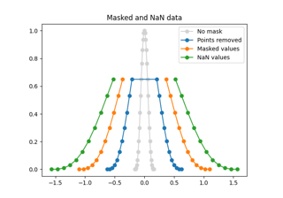

[Plotting masked and NaN values](https://matplotlib.org/stable/gallery/lines_bars_and_markers/masked_demo.html)

Plotting masked and NaN values

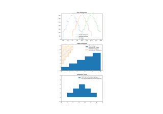

[Stairs Demo](https://matplotlib.org/stable/gallery/lines_bars_and_markers/stairs_demo.html)

Stairs Demo

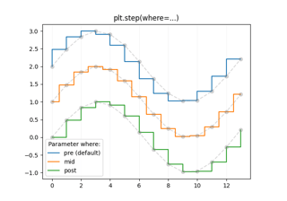

[Step Demo](https://matplotlib.org/stable/gallery/lines_bars_and_markers/step_demo.html)

Step Demo

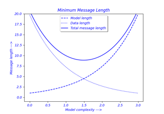

[Findobj Demo](https://matplotlib.org/stable/gallery/misc/findobj_demo.html)

Findobj Demo

[Multipage PDF](https://matplotlib.org/stable/gallery/misc/multipage_pdf.html)

Multipage PDF

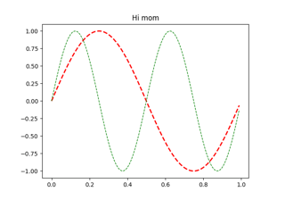

[Set and get properties](https://matplotlib.org/stable/gallery/misc/set_and_get.html)

Set and get properties

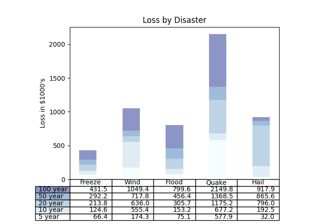

[Table Demo](https://matplotlib.org/stable/gallery/misc/table_demo.html)

Table Demo

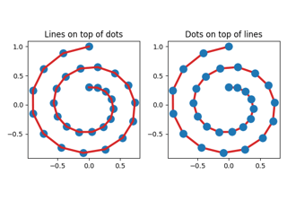

[Zorder Demo](https://matplotlib.org/stable/gallery/misc/zorder_demo.html)

Zorder Demo

[Rotating a 3D plot](https://matplotlib.org/stable/gallery/mplot3d/rotate_axes3d_sgskip.html)

Rotating a 3D plot

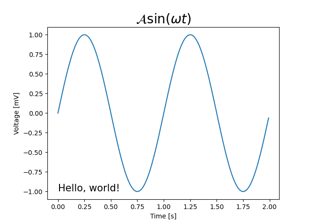

[Text and mathtext using pyplot](https://matplotlib.org/stable/gallery/pyplots/pyplot_text.html)

Text and mathtext using pyplot

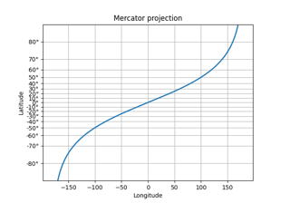

[Custom scale](https://matplotlib.org/stable/gallery/scales/custom_scale.html)

Custom scale

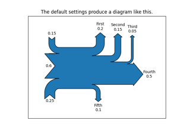

[The Sankey class](https://matplotlib.org/stable/gallery/specialty_plots/sankey_basics.html)

The Sankey class

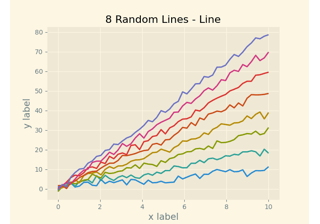

[Solarized Light stylesheet](https://matplotlib.org/stable/gallery/style_sheets/plot_solarizedlight2.html)

Solarized Light stylesheet

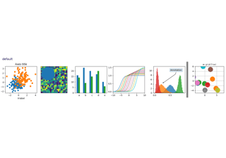

[Style sheets reference](https://matplotlib.org/stable/gallery/style_sheets/style_sheets_reference.html)

Style sheets reference

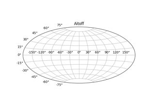

[Geographic Projections](https://matplotlib.org/stable/gallery/subplots_axes_and_figures/geo_demo.html)

Geographic Projections

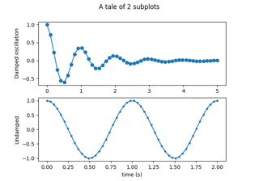

[Multiple subplots](https://matplotlib.org/stable/gallery/subplots_axes_and_figures/subplot.html)

Multiple subplots

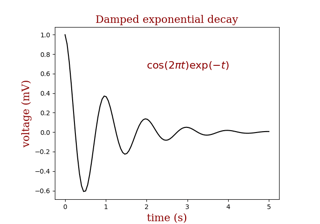

[Controlling style of text and labels using a dictionary](https://matplotlib.org/stable/gallery/text_labels_and_annotations/text_fontdict.html)

Controlling style of text and labels using a dictionary

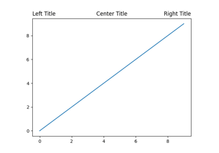

[Title positioning](https://matplotlib.org/stable/gallery/text_labels_and_annotations/titles_demo.html)

Title positioning

[SVG Histogram](https://matplotlib.org/stable/gallery/user_interfaces/svg_histogram_sgskip.html)

SVG Histogram

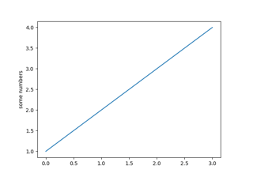

[Pyplot tutorial](https://matplotlib.org/stable/tutorials/pyplot.html)

Pyplot tutorial

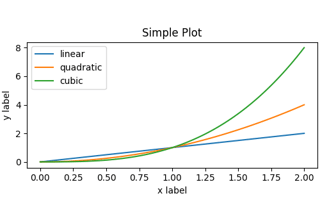

[Quick start guide](https://matplotlib.org/stable/users/explain/quick_start.html)

Quick start guide